# Exploration of Prosper Loan Dataset

## by (Moaz Mohammed El-Essawey)

## Preliminary Wrangling

> The dataset consist of 81 column containg data about loans in U.S that provided the analysts a data to help investigate the effect on the **Borrower APR** by the other variables. in definition the:  
> **Borrower APR** is: the annual cost of a loan to a borrower — including fees.

```python
# import all packages and set plots to be embedded inline
import numpy as np
import pandas as pd
import matplotlib.pyplot as plt
import seaborn as sb

%matplotlib inline
```

> Load in your dataset and describe its properties through the questions below. Try and motivate your exploration goals through this section.

```python
df = pd.read_csv('../data/prosperLoanData.csv')
df.head()
```

|  | ListingKey | ListingNumber | ListingCreationDate | CreditGrade | Term | LoanStatus | ClosedDate | BorrowerAPR | BorrowerRate | LenderYield | EstimatedEffectiveYield | EstimatedLoss | EstimatedReturn | ProsperRating (numeric) | ProsperRating (Alpha) | ProsperScore | ListingCategory (numeric) | BorrowerState | Occupation | EmploymentStatus | EmploymentStatusDuration | IsBorrowerHomeowner | CurrentlyInGroup | GroupKey | DateCreditPulled | CreditScoreRangeLower | CreditScoreRangeUpper | FirstRecordedCreditLine | CurrentCreditLines | … |
| --- | --- | --- | --- | --- | --- | --- | --- | --- | --- | --- | --- | --- | --- | --- | --- | --- | --- | --- | --- | --- | --- | --- | --- | --- | --- | --- | --- | --- | --- | --- |
| 0 | 1021339766868145413AB3B | 193129 | 2007-08-26 19:09:29.263000000 | C | 36 | Completed | 2009-08-14 00:00:00 | 0.16516 | 0.1580 | 0.1380 | NaN | NaN | NaN | NaN | NaN | NaN | 0 | CO | Other | Self-employed | 2.0 | True | True | NaN | 2007-08-26 18:41:46.780000000 | 640.0 | 659.0 | 2001-10-11 00:00:00 | 5.0 | … |
| 1 | 10273602499503308B223C1 | 1209647 | 2014-02-27 08:28:07.900000000 | NaN | 36 | Current | NaN | 0.12016 | 0.0920 | 0.0820 | 0.07960 | 0.0249 | 0.05470 | 6.0 | A | 7.0 | 2 | CO | Professional | Employed | 44.0 | False | False | NaN | 2014-02-27 08:28:14 | 680.0 | 699.0 | 1996-03-18 00:00:00 | 14.0 | … |
| 2 | 0EE9337825851032864889A | 81716 | 2007-01-05 15:00:47.090000000 | HR | 36 | Completed | 2009-12-17 00:00:00 | 0.28269 | 0.2750 | 0.2400 | NaN | NaN | NaN | NaN | NaN | NaN | 0 | GA | Other | Not available | NaN | False | True | 783C3371218786870A73D20 | 2007-01-02 14:09:10.060000000 | 480.0 | 499.0 | 2002-07-27 00:00:00 | NaN | … |
| 3 | 0EF5356002482715299901A | 658116 | 2012-10-22 11:02:35.010000000 | NaN | 36 | Current | NaN | 0.12528 | 0.0974 | 0.0874 | 0.08490 | 0.0249 | 0.06000 | 6.0 | A | 9.0 | 16 | GA | Skilled Labor | Employed | 113.0 | True | False | NaN | 2012-10-22 11:02:32 | 800.0 | 819.0 | 1983-02-28 00:00:00 | 5.0 | … |
| 4 | 0F023589499656230C5E3E2 | 909464 | 2013-09-14 18:38:39.097000000 | NaN | 36 | Current | NaN | 0.24614 | 0.2085 | 0.1985 | 0.18316 | 0.0925 | 0.09066 | 3.0 | D | 4.0 | 2 | MN | Executive | Employed | 44.0 | True | False | NaN | 2013-09-14 18:38:44 | 680.0 | 699.0 | 2004-02-20 00:00:00 | 19.0 | … |

```python
df.info()
```

```
<class 'pandas.core.frame.DataFrame'>
RangeIndex: 113937 entries, 0 to 113936
Data columns (total 81 columns):
 #   Column                               Non-Null Count   Dtype
---  ------                               --------------   -----
 0   ListingKey                           113937 non-null  object
 1   ListingNumber                        113937 non-null  int64
 2   ListingCreationDate                  113937 non-null  object
 3   CreditGrade                          28953 non-null   object
 4   Term                                 113937 non-null  int64
 5   LoanStatus                           113937 non-null  object
 6   ClosedDate                           55089 non-null   object
 7   BorrowerAPR                          113912 non-null  float64
 8   BorrowerRate                         113937 non-null  float64
 9   LenderYield                          113937 non-null  float64
```

[output cut: 73 more lines]

```python
df.isna().sum()
```

```
ListingKey                         0
ListingNumber                      0
ListingCreationDate                0
CreditGrade                    84984
Term                               0
                               ...
PercentFunded                      0
Recommendations                    0
InvestmentFromFriendsCount         0
InvestmentFromFriendsAmount        0
Investors                          0
Length: 81, dtype: int64
```

### What is the structure of your dataset?

> as said the dataset contains `81` column with `113937` observation that contain a null values in it.

### What is/are the main feature(s) of interest in your dataset?

> The dataset contains alot of variables to wrok with but some might have a great impact on the analysis and be useful to work with over other so after some research on loans and how it works specially in the U.S.
> - BorrowerAPR: Borrower Annual Percentage Rate
> - Prosper Rateing

### What features in the dataset do you think will help support your investigation into your feature(s) of interest?

I think than these variable below will have a great impact on the the two variable above.

- **BorrowerAPR**: The Borrower's Annual Percentage Rate (APR) for the loan.
- **Term**: The length of the loan expressed in months.
- **LoanStatus**: The current status of the loan: Cancelled, Chargedoff, Completed, Current, Defaulted, FinalPaymentInProgress, PastDue. The PastDue status will be accompanied by a delinquency bucket.
- **BorrowerState**:The two letter abbreviation of the state of the address of the borrower at the time the Listing was created.
- **EmploymentStatus**: The employment status of the borrower at the time they posted the listing.
- **TotalTrade**: Number of trade lines ever opened at the time the credit profile was pulled.
- **LoanOriginalAmount**: The origination amount of the loan.
- **IncomeRange**: The income range of the borrower at the time the listing was created.
- **StatedMonthlyIncome**: The monthly income the borrower stated at the time the listing was created.
- **InquiriesLast6Months**: Number of inquiries in the past six months at the time the credit profile was pulled.
- **DebtToIncomeRatio**: The debt to income ratio of the borrower at the time the credit profile was pulled. This value is Null if the debt to income ratio is not available. This value is capped at 10.01 (any debt to income ratio larger than 1000% will be returned as 1001%).
- **EstimatedLoss**: Estimated loss is the estimated principal loss on charge-offs. Applicable for loans originated after July 2009.
- **EstimatedReturn**: The estimated return assigned to the listing at the time it was created. Estimated return is the difference between the Estimated Effective Yield and the Estimated Loss Rate. Applicable for loans originated after July 2009.
- **OnTimeProsperPayments**: Number of on time payments the borrower had made on Prosper loans at the time they created this listing. This value will be null if the borrower has no prior loans.
- **ProsperGrade**: The Prosper Rating assigned at the time the listing was created, between AA - HR. The rating assigned by Prosper helps to decide the APR the borrower should be charged.
- **ProsperRating (Alpha)**: The Prosper Rating assigned at the time the listing was created between AA - HR. Applicable for loans originated after July 2009..

all these info can be fount on the excel file included with the zip file or on this link [Here](https://www.prosper.com/Downloads/Services/Documentation/ProsperDataExport_Details.html)

```python
## select the variable (features) to work with in the analysis
features = [
    'BorrowerAPR', 'Term', 'BorrowerState', 'EmploymentStatus', 'LoanStatus','LoanOriginalAmount',
    'IncomeRange', 'StatedMonthlyIncome', 'InquiriesLast6Months', 'DebtToIncomeRatio', 'EstimatedLoss',
    'EstimatedReturn', 'OnTimeProsperPayments', 'ProsperRating (Alpha)', 'ListingKey',
]

df_features = df[features]
df_features
```

|  | BorrowerAPR | Term | BorrowerState | EmploymentStatus | LoanStatus | LoanOriginalAmount | IncomeRange | StatedMonthlyIncome | InquiriesLast6Months | DebtToIncomeRatio | EstimatedLoss | EstimatedReturn | OnTimeProsperPayments | ProsperRating (Alpha) | ListingKey |
| --- | --- | --- | --- | --- | --- | --- | --- | --- | --- | --- | --- | --- | --- | --- | --- |
| 0 | 0.16516 | 36 | CO | Self-employed | Completed | 9425 | $25,000-49,999 | 3083.333333 | 3.0 | 0.17 | NaN | NaN | NaN | NaN | 1021339766868145413AB3B |
| 1 | 0.12016 | 36 | CO | Employed | Current | 10000 | $50,000-74,999 | 6125.000000 | 3.0 | 0.18 | 0.0249 | 0.05470 | NaN | A | 10273602499503308B223C1 |
| 2 | 0.28269 | 36 | GA | Not available | Completed | 3001 | Not displayed | 2083.333333 | 0.0 | 0.06 | NaN | NaN | NaN | NaN | 0EE9337825851032864889A |
| 3 | 0.12528 | 36 | GA | Employed | Current | 10000 | $25,000-49,999 | 2875.000000 | 0.0 | 0.15 | 0.0249 | 0.06000 | NaN | A | 0EF5356002482715299901A |
| 4 | 0.24614 | 36 | MN | Employed | Current | 15000 | $100,000+ | 9583.333333 | 1.0 | 0.26 | 0.0925 | 0.09066 | 11.0 | D | 0F023589499656230C5E3E2 |
| ... | ... | ... | ... | ... | ... | ... | ... | ... | ... | ... | ... | ... | ... | ... | ... |
| 113932 | 0.22354 | 36 | IL | Employed | Current | 10000 | $50,000-74,999 | 4333.333333 | 0.0 | 0.13 | 0.0699 | 0.09500 | NaN | C | E6D9357655724827169606C |
| 113933 | 0.13220 | 36 | PA | Employed | FinalPaymentInProgress | 2000 | $75,000-99,999 | 8041.666667 | 1.0 | 0.11 | 0.0200 | 0.08070 | 60.0 | A | E6DB353036033497292EE43 |
| 113934 | 0.23984 | 60 | TX | Employed | Current | 10000 | $25,000-49,999 | 2875.000000 | 1.0 | 0.51 | 0.1025 | 0.08578 | NaN | D | E6E13596170052029692BB1 |
| 113935 | 0.28408 | 60 | GA | Full-time | Completed | 15000 | $25,000-49,999 | 3875.000000 | 1.0 | 0.48 | 0.0850 | 0.15950 | 16.0 | C | E6EB3531504622671970D9E |
| 113936 | 0.13189 | 36 | NY | Employed | Current | 2000 | $50,000-74,999 | 4583.333333 | 0.0 | 0.23 | 0.0299 | 0.06081 | NaN | A | E6ED3600409833199F711B7 |

113937 rows × 15 columns

```python
df_features.info()
```

```
<class 'pandas.core.frame.DataFrame'>
RangeIndex: 113937 entries, 0 to 113936
Data columns (total 15 columns):
 #   Column                 Non-Null Count   Dtype
---  ------                 --------------   -----
 0   BorrowerAPR            113912 non-null  float64
 1   Term                   113937 non-null  int64
 2   BorrowerState          108422 non-null  object
 3   EmploymentStatus       111682 non-null  object
 4   LoanStatus             113937 non-null  object
 5   LoanOriginalAmount     113937 non-null  int64
 6   IncomeRange            113937 non-null  object
 7   StatedMonthlyIncome    113937 non-null  float64
 8   InquiriesLast6Months   113240 non-null  float64
 9   DebtToIncomeRatio      105383 non-null  float64
 10  EstimatedLoss          84853 non-null   float64
 11  EstimatedReturn        84853 non-null   float64
 12  OnTimeProsperPayments  22085 non-null   float64
 13  ProsperRating (Alpha)  84853 non-null   object
 14  ListingKey             113937 non-null  object
dtypes: float64(7), int64(2), object(6)
memory usage: 13.0+ MB
```

```python
df_features.isna().sum()
```

```
BorrowerAPR                 25
Term                         0
BorrowerState             5515
EmploymentStatus          2255
LoanStatus                   0
LoanOriginalAmount           0
IncomeRange                  0
StatedMonthlyIncome          0
InquiriesLast6Months       697
DebtToIncomeRatio         8554
EstimatedLoss            29084
EstimatedReturn          29084
OnTimeProsperPayments    91852
ProsperRating (Alpha)    29084
ListingKey                   0
dtype: int64
```

```python
## drop any duplicates rows from the selected dataframe
df_features = df_features.drop_duplicates()
df_features.shape
```

[output not shown]

```python
## as my goal here is to work with data to figure out the ProsperRating (Alpha) columns
## I will drop any null values in this column from entire dataset.

df_features = df_features[~df_features['ProsperRating (Alpha)'].isna()]

## fill the NaN values in DebtIncomeRatio with the median as the distrebution
## will be right skewed as we will show down in the Univariate Visuals
df_features['DebtToIncomeRatio'].fillna(df_features['DebtToIncomeRatio'].median(), inplace=True)
df_features.head()
```

|  | BorrowerAPR | Term | BorrowerState | EmploymentStatus | LoanStatus | LoanOriginalAmount | IncomeRange | StatedMonthlyIncome | InquiriesLast6Months | DebtToIncomeRatio | EstimatedLoss | EstimatedReturn | OnTimeProsperPayments | ProsperRating (Alpha) | ListingKey |
| --- | --- | --- | --- | --- | --- | --- | --- | --- | --- | --- | --- | --- | --- | --- | --- |
| 1 | 0.12016 | 36 | CO | Employed | Current | 10000 | $50,000-74,999 | 6125.000000 | 3.0 | 0.18 | 0.0249 | 0.05470 | NaN | A | 10273602499503308B223C1 |
| 3 | 0.12528 | 36 | GA | Employed | Current | 10000 | $25,000-49,999 | 2875.000000 | 0.0 | 0.15 | 0.0249 | 0.06000 | NaN | A | 0EF5356002482715299901A |
| 4 | 0.24614 | 36 | MN | Employed | Current | 15000 | $100,000+ | 9583.333333 | 1.0 | 0.26 | 0.0925 | 0.09066 | 11.0 | D | 0F023589499656230C5E3E2 |
| 5 | 0.15425 | 60 | NM | Employed | Current | 15000 | $100,000+ | 8333.333333 | 0.0 | 0.36 | 0.0449 | 0.07077 | NaN | B | 0F05359734824199381F61D |
| 6 | 0.31032 | 36 | KS | Employed | Current | 3000 | $25,000-49,999 | 2083.333333 | 0.0 | 0.27 | 0.1275 | 0.11070 | NaN | E | 0F0A3576754255009D63151 |

```python
df_features.info()
```

```
<class 'pandas.core.frame.DataFrame'>
Int64Index: 83982 entries, 1 to 113936
Data columns (total 15 columns):
 #   Column                 Non-Null Count  Dtype
---  ------                 --------------  -----
 0   BorrowerAPR            83982 non-null  float64
 1   Term                   83982 non-null  int64
 2   BorrowerState          83982 non-null  object
 3   EmploymentStatus       83982 non-null  object
 4   LoanStatus             83982 non-null  object
 5   LoanOriginalAmount     83982 non-null  int64
 6   IncomeRange            83982 non-null  object
 7   StatedMonthlyIncome    83982 non-null  float64
 8   InquiriesLast6Months   83982 non-null  float64
 9   DebtToIncomeRatio      83982 non-null  float64
 10  EstimatedLoss          83982 non-null  float64
 11  EstimatedReturn        83982 non-null  float64
 12  OnTimeProsperPayments  19635 non-null  float64
 13  ProsperRating (Alpha)  83982 non-null  object
 14  ListingKey             83982 non-null  object
dtypes: float64(7), int64(2), object(6)
memory usage: 10.3+ MB
```

```python
df_features.isna().sum()
```

```
BorrowerAPR                  0
Term                         0
BorrowerState                0
EmploymentStatus             0
LoanStatus                   0
LoanOriginalAmount           0
IncomeRange                  0
StatedMonthlyIncome          0
InquiriesLast6Months         0
DebtToIncomeRatio            0
EstimatedLoss                0
EstimatedReturn              0
OnTimeProsperPayments    64347
ProsperRating (Alpha)        0
ListingKey                   0
dtype: int64
```

## Univariate Exploration

> In this section, investigate distributions of individual variables. If you see unusual points or outliers, take a deeper look to clean things up and prepare yourself to look at relationships between variables.

### The Distrebution of BorrowerAPR.

```python
pd.DataFrame(df_features['BorrowerAPR'].describe()).T
```

|  | count | mean | std | min | 25% | 50% | 75% | max |
| --- | --- | --- | --- | --- | --- | --- | --- | --- |
| BorrowerAPR | 83982.0 | 0.226945 | 0.080047 | 0.04583 | 0.16361 | 0.21945 | 0.29254 | 0.42395 |

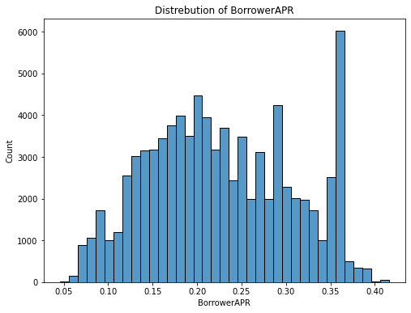

```python
plt.figure(figsize=(8, 6))
borrower_apr_bins = np.arange(
    df_features['BorrowerAPR'].min(),
    df_features['BorrowerAPR'].max(),
    0.01
)
sb.histplot(data=df_features, x='BorrowerAPR', bins=borrower_apr_bins)
plt.title('Distrebution of BorrowerAPR');
```

### Distrebution of Employment Status

```python
pd.DataFrame(df_features['EmploymentStatus'].value_counts().sort_values(ascending=False)).T
```

|  | Employed | Full-time | Self-employed | Other | Not employed | Retired | Part-time |
| --- | --- | --- | --- | --- | --- | --- | --- |
| EmploymentStatus | 66586 | 7926 | 4456 | 3742 | 649 | 367 | 256 |

Employmed clients has the most proportion in the data with **67K** members in the dataset.

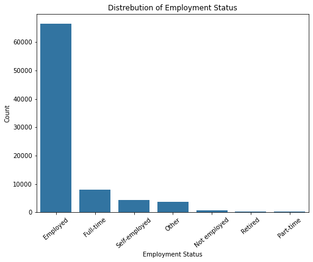

```python
plt.figure(figsize=(8, 6))
base_color = sb.color_palette()[0]
status_order = df_features['EmploymentStatus'].value_counts().sort_values(ascending=False).index
sb.countplot(data=df_features, x='EmploymentStatus', color=base_color, order=status_order)
plt.xticks(rotation=40);
plt.title('Distrebution of Employment Status')
plt.xlabel('Employment Status')
plt.ylabel('Count');
```

As shown above the Employed clients have more count than other which is obvious cause they have like an isurance or something that they might light on to bay for the loan. as compared to the Not employed clients whom have the least count. and those whom are retired too.

### Distrebution of IncomeRange.

```python
pd.DataFrame(df_features['IncomeRange'].value_counts().sort_values(ascending=False)).T
```

|  | $50,000-74,999 | $25,000-49,999 | $100,000+ | $75,000-99,999 | $1-24,999 | Not employed | $0 |
| --- | --- | --- | --- | --- | --- | --- | --- |
| IncomeRange | 25326 | 23923 | 15056 | 14362 | 4621 | 649 | 45 |

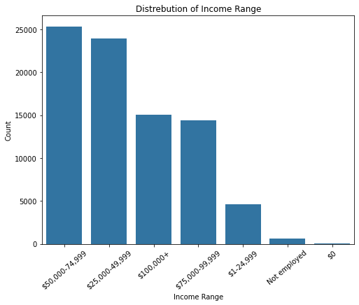

```python
plt.figure(figsize=(8, 6))
base_color = sb.color_palette()[0]
status_order = df_features['IncomeRange'].value_counts().sort_values(ascending=False).index
sb.countplot(data=df_features, x='IncomeRange', color=base_color, order=status_order)
plt.xticks(rotation=40);
plt.title('Distrebution of Income Range')
plt.xlabel('Income Range')
plt.ylabel('Count');
```

**IncomeRange** has a great impact on a client will take a loan or not as the above figure shows:

- client with IncomeRange **25,000-49,999** and **50,000-74,999** have the most count of loans been taken and
- and the **Not Employed** and **No Income** income have the least change to take a loan.

### Distrebution of Loan Amount

```python
pd.DataFrame(df_features['LoanOriginalAmount'].describe()).T
```

|  | count | mean | std | min | 25% | 50% | 75% | max |
| --- | --- | --- | --- | --- | --- | --- | --- | --- |
| LoanOriginalAmount | 83982.0 | 9061.224381 | 6279.649648 | 1000.0 | 4000.0 | 7500.0 | 13500.0 | 35000.0 |

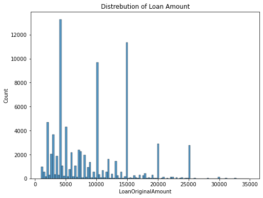

```python
plt.figure(figsize=(8, 6))
loan_amountbins = np.arange(
    df_features['LoanOriginalAmount'].min(),
    df_features['LoanOriginalAmount'].max(),
    300.
)
sb.histplot(data=df_features, x='LoanOriginalAmount', bins=loan_amountbins)
plt.title('Distrebution of Loan Amount');
```

from the first glance the data is right skewed which is okay when dealing with money. but there is some peaks that need for investigation:

- around **5K**
- around **10K**
- around **16K**
- around **20K** and **26K**

### Disterbution of Estimated Loss.

```python
pd.DataFrame(df_features['EstimatedLoss'].describe()).T
```

|  | count | mean | std | min | 25% | 50% | 75% | max |
| --- | --- | --- | --- | --- | --- | --- | --- | --- |
| EstimatedLoss | 83982.0 | 0.080417 | 0.046851 | 0.0049 | 0.0424 | 0.0724 | 0.112 | 0.366 |

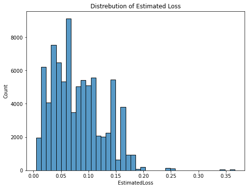

```python
plt.figure(figsize=(8, 6))

sb.histplot(data=df_features, x='EstimatedLoss', bins=40)
plt.title('Distrebution of Estimated Loss');
```

the distrebution is also quite right skewed with some peaks in the data and also some gaps which might relates to the NaN values in the data.

### Distrebution of DebtToIncomeRatio

```python
pd.DataFrame(df_features['DebtToIncomeRatio'].describe()).T
```

|  | count | mean | std | min | 25% | 50% | 75% | max |
| --- | --- | --- | --- | --- | --- | --- | --- | --- |
| DebtToIncomeRatio | 83982.0 | 0.255369 | 0.305879 | 0.0 | 0.16 | 0.22 | 0.31 | 10.01 |

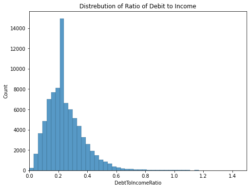

```python
plt.figure(figsize=(8, 6))
income_ratio_bins = np.arange(
    df_features['DebtToIncomeRatio'].min(),
    df_features['DebtToIncomeRatio'].max(),
    0.03
)
sb.histplot(data=df_features, x='DebtToIncomeRatio', bins=income_ratio_bins)
plt.xlim((0, 1.5))
plt.title('Distrebution of Ratio of Debit to Income');
```

the **DebtToIncomeRatio** is pure right skewed histogram and have a lot outlires so thats why i set the `xlim` to `(0, 1.5)` to adjust the graph. with unusal peak around `0.24`

### Distrebution of Credit Grade

```python
pd.DataFrame(df_features['ProsperRating (Alpha)'].value_counts().sort_values(ascending=False)).T
```

|  | C | B | A | D | E | HR | AA |
| --- | --- | --- | --- | --- | --- | --- | --- |
| ProsperRating (Alpha) | 18096 | 15368 | 14390 | 14170 | 9716 | 6917 | 5325 |

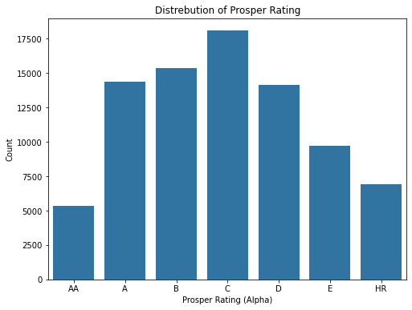

```python
plt.figure(figsize=(8, 6))
base_color = sb.color_palette()[0]
prosper_rating_order = ['AA', 'A', 'B', 'C', 'D', 'E', 'HR']

sb.countplot(data=df_features, x='ProsperRating (Alpha)', color=base_color, order=prosper_rating_order)
plt.title('Distrebution of Prosper Rating')
plt.xlabel('Prosper Rating (Alpha)')
plt.ylabel('Count');
```

### Amount of Loans in each BorrowerState

```python
borrower_state_loan_counts = (
    df_features['BorrowerState']
    .value_counts()
    .reset_index()
    .rename(columns={'index': 'State', 'BorrowerState': 'Count'})
)
borrower_state_loan_counts.head()
```

|  | State | Count |
| --- | --- | --- |
| 0 | CA | 10638 |
| 1 | NY | 5775 |
| 2 | TX | 5578 |
| 3 | FL | 5353 |
| 4 | IL | 4215 |

```python
## create a map of US to show the count of loans in each US State
from plotly import graph_objects as go


graph_obj = go.Choropleth(
    locations=borrower_state_loan_counts['State'],
    z = borrower_state_loan_counts['Count'],
    locationmode = 'USA-states',
    colorscale = 'Blues',
    colorbar_title = "Loan Counts",
)

fig = go.Figure(data=graph_obj)

fig.update_layout(
    title_text = 'Loan Count in each U.S State',
    geo_scope='usa',
)

fig.show()

##the output might not show in the html version so i provided a png image of a saved version of the graph
```

[interactive chart not shown]

[figure not shown]

### Were there any unusual points? Did you need to perform any transformations?

#### Unsual Points:

- The Distrebution of **LoanOriginalAmount** has some unsual peaks around the **5K,10K, 16K, 20K, and 26K**.
- The Distrebution of **BorrowerAPR** has a unimodal shape with an usual peak at `0.35`.  
  -The Distrebution of **DebtToIncomeRatio** also has a unimodal shape with an usual peak around `0.2`.

the data need no transformation.

### Of the features investigated, were there any unusual distributions? Did you perform any operations on the data to tidy, adjust, or change the form of the data? If so, why did you do this?

**DebtToIncomeRatio**, **EstimatedLoss** has a right skewed with a unimodal shape.

#### Tidy and Cleaning:

- Removed any value from the data that has a NaN value in the ProsperRating (Alpha) which reduced the size of the data by `30k` observation.
- fill the NaN values in the **DebtToIncomeRatio** by it's `median`.

## Bivariate Exploration

> In this section, investigate relationships between pairs of variables in your data. Make sure the variables that you cover here have been introduced in some fashion in the previous section (univariate exploration).

### Relation between the ProsperRating (Alpha) and BorrowerAPR.

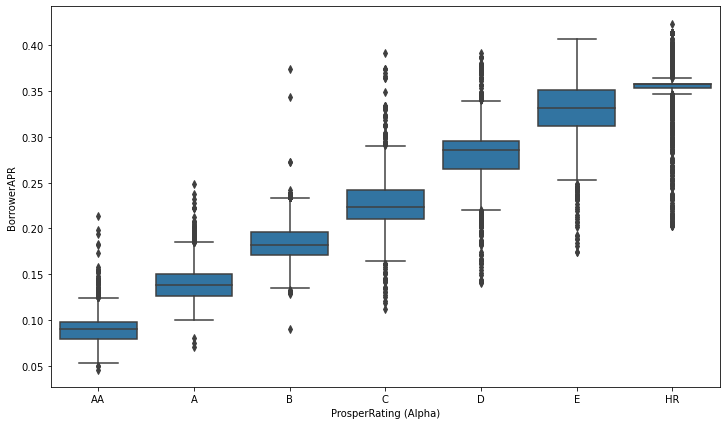

```python
plt.figure(figsize=(12, 7))

sb.boxplot(data=df_features, x='ProsperRating (Alpha)', y='BorrowerAPR',
           color=base_color, order=prosper_rating_order)
```

### Relation between the IncomeRange and BorrowerAPR.

```python
df_features['IncomeRange'].unique()
```

```
array(['$50,000-74,999', '$25,000-49,999', '$100,000+', '$75,000-99,999',
       '$1-24,999', 'Not employed', '$0'], dtype=object)
```

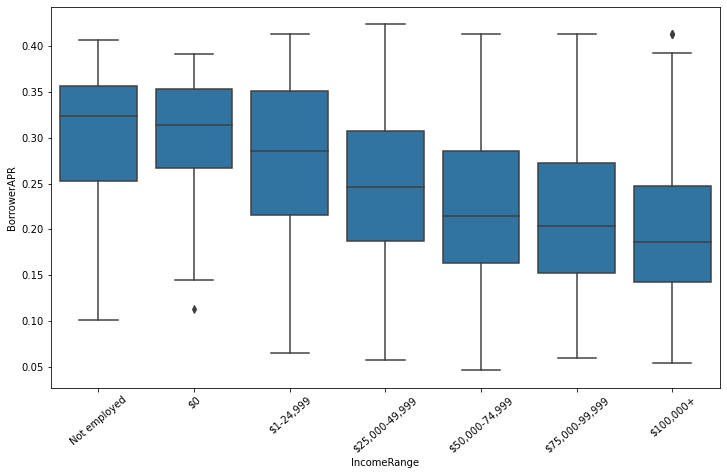

```python
plt.figure(figsize=(12, 7))
income_range_order = ['Not employed', '$0', '$1-24,999', '$25,000-49,999',
                      '$50,000-74,999', '$75,000-99,999', '$100,000+'
]

sb.boxplot(data=df_features, x='IncomeRange', y='BorrowerAPR',
           color=base_color, order=income_range_order)
plt.xticks(rotation=40);
```

The Borrower Annual Percentage Rate (**BorrowerAPR**) tends to decrease with an increase in the **IncomeRange**.  
but still all income ranges has the same range in the **BorrowerAPR**. with smaller range in the **0** range.

### Relation between the Loan Amount and BorrowerAPR

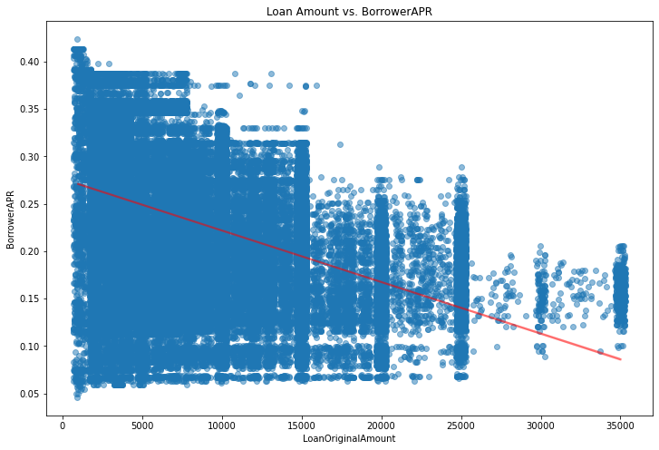

```python
plt.figure(figsize=(12, 8))
sb.regplot(data=df_features, x='LoanOriginalAmount', y='BorrowerAPR',
           scatter_kws={'alpha':.5}, line_kws={'alpha': .5, 'color': 'r'}, x_jitter=300)
plt.title('Loan Amount vs. BorrowerAPR')
```

The data has a Negative Correlation as the **LoanOriginalAmount** increases the **BorrowerAPR** tends to decrease.  
most of the loans lies between (**0**, **15K**) and small portion lies between the (**25K**, **35K**)

### Correlation between numeric variabls.

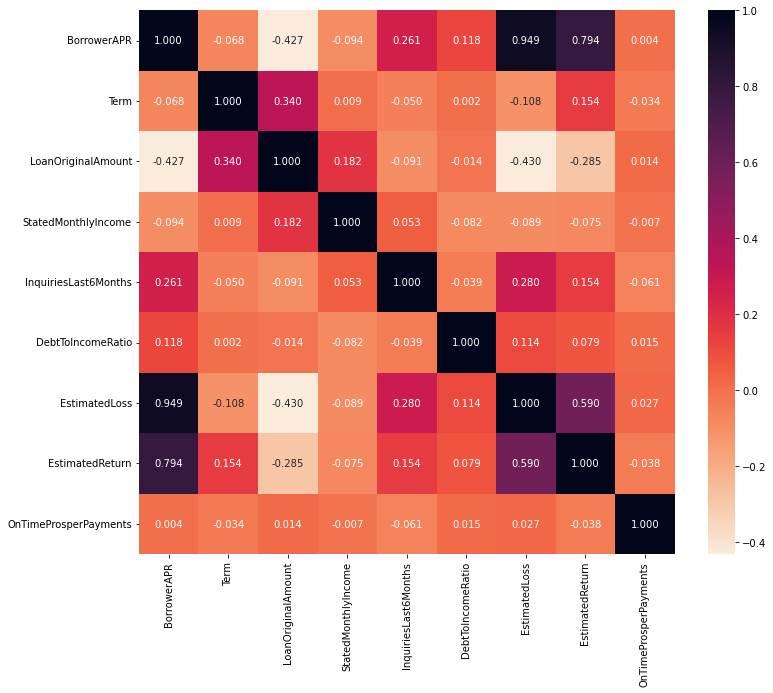

```python
numeric_cols_df = df_features.select_dtypes(['int', 'float'])
numeric_cols_df_corr = numeric_cols_df.corr()

plt.figure(figsize=(12, 10))
sb.heatmap(numeric_cols_df_corr, annot=True, fmt='.3f', cmap='rocket_r')
```

The heatmap is kind obvious as it represent the relation and correltation values between the numeric values in the dataframe with:

**Positive Corr**:

- EstimatedLoss
- EstimatedReturn
- InquiriesLast6Months
- DebtToIncomeRatio

**Negative Corr**:

- StatedMonthlyIncome
- LoanOriginalAmount

and those corr values are with respect to the **BorrowerAPR** column.

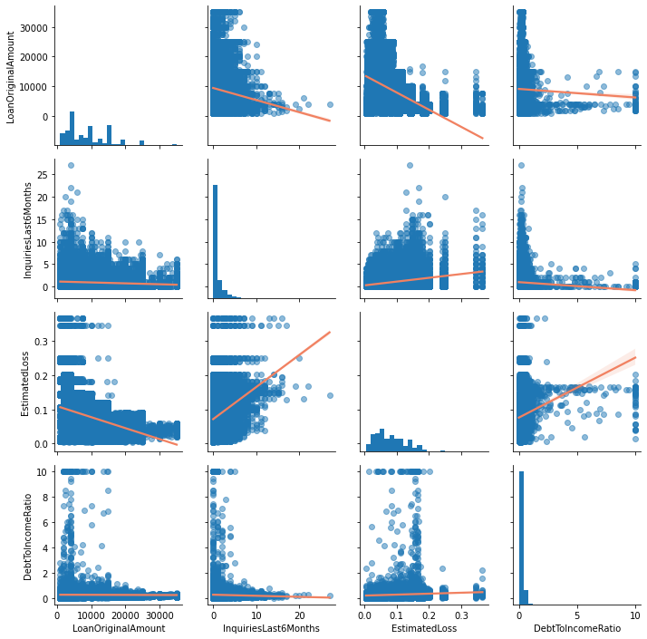

```python
selected_variables = ['LoanOriginalAmount', 'InquiriesLast6Months', 'EstimatedLoss', 'DebtToIncomeRatio']

g = sb.PairGrid(data=numeric_cols_df, x_vars=selected_variables, y_vars=selected_variables)
g.map_diag(plt.hist, bins=25)
g.map_offdiag(sb.regplot, scatter_kws={'alpha': .5}, line_kws={'color': '#f18161'})
```

the above graph show the relation between the variables selected above and shows the same insights that the heatmap shows bu with more detailed.

### Relation between the IncomeRange and ProsperRating (Alpha)

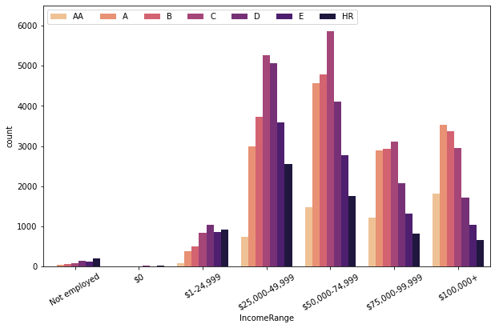

```python
plt.figure(figsize=(10, 6))
sb.countplot(data=df_features, x='IncomeRange', hue='ProsperRating (Alpha)',
             palette='magma_r', order=income_range_order, hue_order=prosper_rating_order)
plt.xticks(rotation=30);
plt.ylim((0, 6500))
plt.legend(ncol=7, loc='upper left');
```

the ProsperRating has an impact on the IncomeRange and the number of loan associated with each. as in **IncomeRanges** in (**25K:50K**, **50K:75K**, **75K:100K**) has a Prosper Rating as **C**. and in the **>100K** we start to see that the Borrowers with **A** and **AA** increasing.

### Disterbution of BorrowerAPR for each IncomeRange

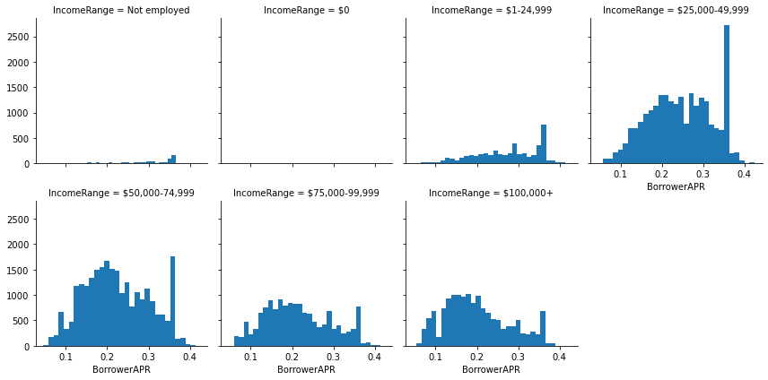

```python
g = sb.FacetGrid(data=df_features, col='IncomeRange', col_wrap=4, col_order=income_range_order)
g.map(plt.hist, 'BorrowerAPR', bins=30)
```

### Relation between the EstimatedLoss and BorrowerAPR

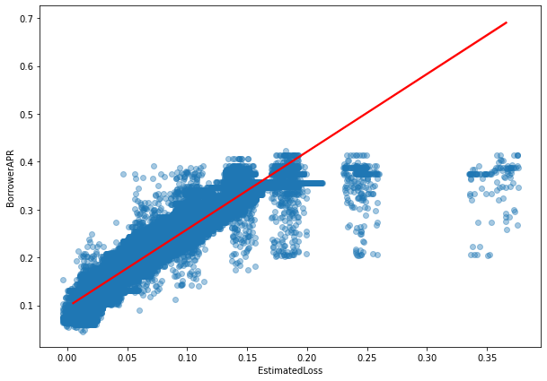

```python
plt.figure(figsize=(10, 7))
sb.regplot(data=df_features, x='EstimatedLoss', y='BorrowerAPR',
           scatter_kws={'alpha': .4}, x_jitter=.01, line_kws={'color': 'red'})
```

the relation is very positivly correlated as it shows that as the **EstimatedLoss** increases the **BorrowerAPR** also increases.

### Talk about some of the relationships you observed in this part of the investigation. How did the feature(s) of interest vary with other features in the dataset?

> the relation between the **BorrowerAPR** and **LoanOriginalAmount** is found to **Negative** which mean as the Loan Amount increases we expect the APR to decrease. which might due to the **ProsperRating**.

### Did you observe any interesting relationships between the other features (not the main feature(s) of interest)?

> the **EstimatedLoss** has a high positivly correlation with the **BorrowerAPR**  
> also the **BorrwerAPR** is very low for those whom are safe borrwers as compared to those whom are risky borrwers.

## Multivariate Exploration

> Create plots of three or more variables to investigate your data even further. Make sure that your investigations are justified, and follow from your work in the previous sections.

### Relation between the EstimatedLoss and BorrowerAPR and effect of EmploymentStatus

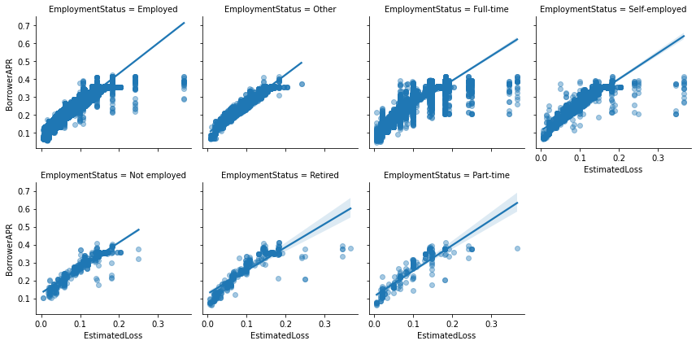

```python
g = sb.FacetGrid(data=df_features, col='EmploymentStatus', col_wrap=4, margin_titles=True)
g.map(sb.regplot, 'EstimatedLoss', 'BorrowerAPR', scatter_kws={'alpha': .4})
```

the **EmploymentStatus** has no effect on teh relation between the **EstimatedLoss** and the **BorrowerAPR** as all value are positivly correlated, but for (**Self-emplymed**, **Full-time**, **Part-time**, **Retired**) we have some outliers that might affect the correlation value, but still positivly correlated.

### Relation between the LoanOrignalAmount and BorrowerAPR and effect of IncomeRange

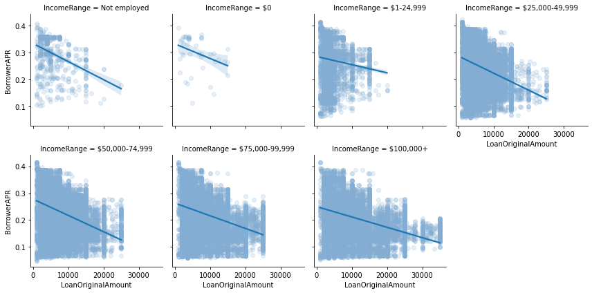

```python
g = sb.FacetGrid(data=df_features, col='IncomeRange', col_wrap=4, margin_titles=True, col_order=income_range_order)
g.map(sb.regplot, 'LoanOriginalAmount', 'BorrowerAPR', scatter_kws={'alpha': .2, 'color': '#83add3'})
```

IcomeRange does not have an effect on the relation between the **BorrowerAPR** and **LoanOriginalAmount** as all types has a Negative Correlation as the

- the LoanOriginalAmount **Increase** the BorrowerAPR value **Decreases**
- there is very small amount of clients are found with Income Range less then **20K** to **0** income.

### Relation between the LoanOrignalAmount and BorrowerAPR and effect of ProsperRating (Alpha)

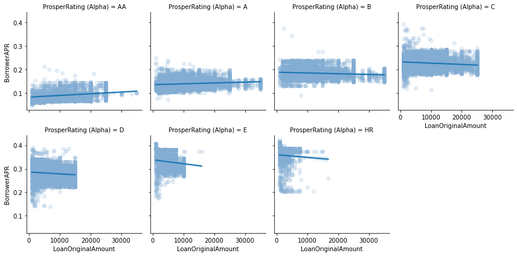

```python
g = sb.FacetGrid(data=df_features, col='ProsperRating (Alpha)', col_wrap=4,
                 margin_titles=True, col_order=prosper_rating_order)
g.map(sb.regplot, 'LoanOriginalAmount', 'BorrowerAPR',
      scatter_kws={'alpha': .2, 'color': '#83add3'})
```

**ProsperRating (Alpha)** has a great effect on the relation between **LoanOriginalAmount** and **BorrowerAPR** as the overall relation is **Negative** but the relation differ from one ProsperRating to another as it:

**Negative** for :

- HR
- E
- D
- C
- B

and **Positive** for :

- AA
- A

which means that the clients with (**A**, **AA**) rating when the Loan Amount increases the BorrowerAPR increases.

that why the overall correlation is Negative cause most data in ProsperRating (Alpha) have Negative data

### BorrowerAPR by the EmplymentStatus and Term

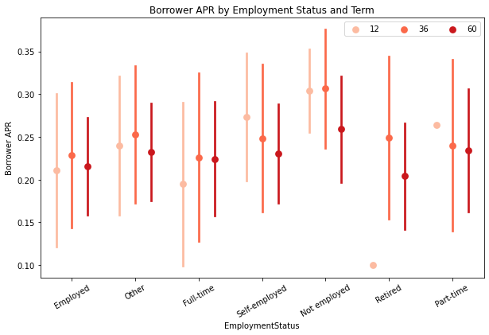

```python
fig = plt.figure(figsize = [10,6])
sb.pointplot(data = df_features, x = 'EmploymentStatus',
                  y = 'BorrowerAPR', hue = 'Term', palette = 'Reds',
                  linestyles = '', dodge = 0.5, ci='sd'
)
plt.title('Borrower APR by Employment Status and Term')
plt.ylabel('Borrower APR')
plt.xticks(rotation = 30);
plt.legend(ncol=3);
```

### BorrowerAPR vs ProserRating and Term

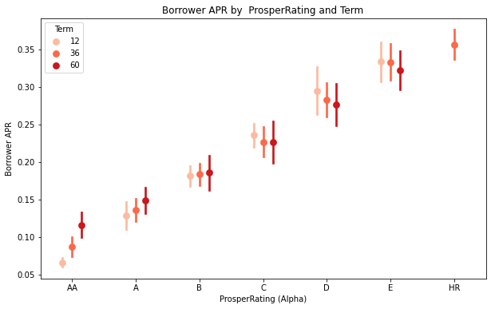

```python
fig = plt.figure(figsize = [10,6])
sb.pointplot(data = df_features, x = 'ProsperRating (Alpha)',
                  y = 'BorrowerAPR', hue = 'Term', palette = 'Reds',
                  linestyles = '', dodge = .3, ci='sd', order=prosper_rating_order
)
plt.title('Borrower APR by  ProsperRating and Term')
plt.ylabel('Borrower APR');
```

For **ProsperRating** relation with **BrowerAPR** we see intersting outcomes as

- the **Term** increase for Borrowers with (**A**, **AA**, **B**) we see increase in teh **BorrowerAPR**.
- and for the (**C**,**D**,**E**) we that is opposite of that as it started to decrease as the **Term** increased

### Talk about some of the relationships you observed in this part of the investigation. Were there features that strengthened each other in terms of looking at your feature(s) of interest?

> ProsperRating has a great impact on the relation between the LoanOriginalAmount and the BorrowerAPR which as showed Here the ProserRating had showed different relations between the two variables!  
> as for ProsperRating with (A, AA) we see postive correlation and for (B, C, D, E) we show negative correlation.

### Were there any interesting or surprising interactions between features?

> Interseting enough the BorrwerAPR tends to increase with increase in the Term for (A, AA, B) and tends to decrease for (C, D, E) which is quit intersting if link that with what we found Here might be useful.

```python
## export the cleaned data to use in the slides deck creation
df_features.to_csv('fromated_data.csv', index=False)
```